# Homework 04

## Question 1: Signal strength and correlated substitutes

Consider a regression problem with $n=120$ observations and $p=10$ covariates. Create one simulated dataset as follows. Generate the first covariate $X_1$ as $n$ independent standard normal draws. Then form the second covariate as

$$X_2 = 0.999X_1 + \sqrt{1-0.999^2}\,Z,$$

where $Z$ is another vector of $n$ independent standard normal draws, so that $X_1$ and $X_2$ have population correlation $0.999$. Generate the remaining covariates $X_3,\ldots,X_{10}$ as independent standard normal vectors of length $n$.

Thus $X_1$ and $X_2$ are extremely highly correlated, while $X_3$ and $X_4$ are independent of one another and of the remaining covariates. Finally, generate the response as

$$Y
=
0.15X_1
+0.15X_2
+0.30X_3
+0.15X_4
+\epsilon,$$

where $\epsilon$ is a vector of $n$ independent standard normal errors, independent of the covariates. Both members of the correlated pair appear in the generating equation with the same coefficient, even though each one carries almost the same observed information as the other. The two independent signals $X_3$ and $X_4$ have coefficients that differ by a factor of two, and $X_5,\ldots,X_{10}$ have zero coefficients.

Use seed `43246` and independently repeat the complete data generation and fitting procedure 200 times. Within each repetition, center and standardize the covariates using divisor $n$ and center the response. Fit the lasso model with the `glmnet` package in R or `sklearn.linear_model.Lasso` in Python, without scaling the variables inside the fitting function, at

$$\lambda\in\{0.08,0.12,0.18,0.24\}.$$

Make sure you understand which argument specifies the scaling option in a lasso fit and how to give a specific penalty value; the default settings of the fitting function do not produce the fits required here.

Fit all four penalties to the same generated dataset before beginning the next repetition. Leave the intercept unpenalized and convert the fitted slopes back to the original covariate scale. Store the slopes in one array whose dimensions correspond to the 200 repetitions, 10 covariates, and four penalties. Treat a slope as nonzero when its absolute value exceeds $10^{-8}$. Use a tight convergence tolerance as well as a sufficiently large iteration limit, because the nearly identical covariates make coefficient allocation sensitive to numerical accuracy. In R, use `control = list(thresh = 1e-18, maxit = 1000000)`; in Python, use `tol=1e-10, max_iter=100000`. Verify that all 800 fits converge. R and Python use different random-number generators, so their exact numerical results need not agree.

1. For every covariate and penalty, report the selection frequency and the mean absolute fitted slope, where the mean includes fitted zeros. Draw one figure for each summary. Explain how increasing the penalty changes the fitted magnitudes and selection frequencies.
2. For the pair $(X_1,X_2)$, report the frequency of four mutually exclusive outcomes at each penalty: only the first covariate is selected, only the second is selected, both are selected, and neither is selected. Compare the two marginal selection frequencies and explain why they are similar. Describe how the four outcomes shift as the penalty increases, and explain why lasso can produce a sparse fitted rule that omits one member of the pair even though both members appear in the generating equation.
3. Compare the selection frequencies of $X_3$ and $X_4$ with the average selection frequency among $X_5,\ldots,X_{10}$. Explain how signal magnitude and the penalty account for the pattern. Use the correlated pair to explain why a fitted zero does not establish that the corresponding population coefficient is zero, and why a nonzero fitted coefficient does not establish that the variable is uniquely important.

## Solution to Question 1

### (a)

**Show the workflow**

```r
library(glmnet)
```

**Show the workflow**

```r
set.seed(43246)

q1_n <- 120
q1_p <- 10
q1_n_reps <- 200
q1_lambdas <- c(0.08, 0.12, 0.18, 0.24)

q1_fit_lasso <- function(X, y, scales, lambda) {
  fit <- glmnet(
    X, y,
    family = gaussian(),
    alpha = 1,
    lambda = lambda,
    intercept = TRUE,
    standardize = FALSE,
    thresh = 1e-18,
    maxit = 1000000
  )

  list(
    slopes = drop(as.matrix(fit$beta)) / scales,
    converged = fit$jerr == 0
  )
}

q1_slopes <- array(
  0,
  dim = c(q1_n_reps, q1_p, length(q1_lambdas)),
  dimnames = list(NULL, paste0("X", seq_len(q1_p)), q1_lambdas)
)
q1_converged <- logical(q1_n_reps * length(q1_lambdas))
q1_fit_index <- 1

for (replication in seq_len(q1_n_reps)) {
  q1_x1 <- rnorm(q1_n)
  q1_x2 <- 0.999 * q1_x1 + sqrt(1 - 0.999^2) * rnorm(q1_n)
  q1_x_remaining <- matrix(
    rnorm(q1_n * (q1_p - 2)),
    nrow = q1_n,
    ncol = q1_p - 2
  )
  q1_X_raw <- cbind(q1_x1, q1_x2, q1_x_remaining)

  q1_y <- 0.15 * q1_x1 + 0.15 * q1_x2 +
    0.30 * q1_X_raw[, 3] + 0.15 * q1_X_raw[, 4] + rnorm(q1_n)

  q1_X_centered <- sweep(q1_X_raw, 2, colMeans(q1_X_raw), "-")
  q1_scales <- sqrt(colMeans(q1_X_centered^2))
  q1_X <- sweep(q1_X_centered, 2, q1_scales, "/")
  q1_y_centered <- q1_y - mean(q1_y)

  for (lambda_index in seq_along(q1_lambdas)) {
    q1_fit <- q1_fit_lasso(
      q1_X,
      q1_y_centered,
      q1_scales,
      q1_lambdas[lambda_index]
    )

    q1_slopes[replication, , lambda_index] <- q1_fit$slopes
    q1_converged[q1_fit_index] <- q1_fit$converged
    q1_fit_index <- q1_fit_index + 1
  }
}

stopifnot(all(q1_converged))

q1_selection_frequency <- sapply(
  seq_along(q1_lambdas),
  function(lambda_index) {
    colMeans(abs(q1_slopes[, , lambda_index]) > 1e-8)
  }
)

q1_mean_absolute_slope <- sapply(
  seq_along(q1_lambdas),
  function(lambda_index) {
    colMeans(abs(q1_slopes[, , lambda_index]))
  }
)

q1_plot_colors <- grDevices::hcl.colors(q1_p, palette = "Dark 3")

dimnames(q1_selection_frequency) <- list(
  paste0("X", seq_len(q1_p)), q1_lambdas
)
dimnames(q1_mean_absolute_slope) <- list(
  paste0("X", seq_len(q1_p)), q1_lambdas
)

q1_selection_frequency
```

```
     0.08  0.12  0.18  0.24
X1  0.480 0.445 0.390 0.335
X2  0.575 0.530 0.500 0.390
X3  0.985 0.965 0.910 0.700
X4  0.735 0.595 0.320 0.150
X5  0.355 0.165 0.065 0.015
X6  0.370 0.210 0.060 0.020
X7  0.350 0.205 0.065 0.005
X8  0.370 0.185 0.040 0.010
X9  0.390 0.210 0.105 0.010
X10 0.325 0.190 0.075 0.010
```

**Show the workflow**

```r
q1_mean_absolute_slope
```

```
          0.08        0.12        0.18         0.24
X1  0.09858937 0.079331876 0.053609704 0.0323928715
X2  0.11204008 0.092231625 0.062959468 0.0372494995
X3  0.21773100 0.178639269 0.123090375 0.0745696868
X4  0.07481758 0.047723969 0.020918751 0.0072000679
X5  0.01957327 0.009243504 0.002881287 0.0008512618
X6  0.02243823 0.010408743 0.003034750 0.0006728361
X7  0.02130091 0.010316634 0.002302390 0.0002527433
X8  0.01900139 0.007657212 0.001117944 0.0001629014
X9  0.02389219 0.012426509 0.002748162 0.0001768304
X10 0.01831430 0.009112591 0.002048705 0.0001802824
```

The data-generating coefficients are fixed, but each repetition has new predictors and new noise. For each dataset, all four penalties are fitted before generating the next dataset. As lambda increases, the stronger penalty generally reduces fitted magnitudes and makes selections less frequent.

**Show the workflow**

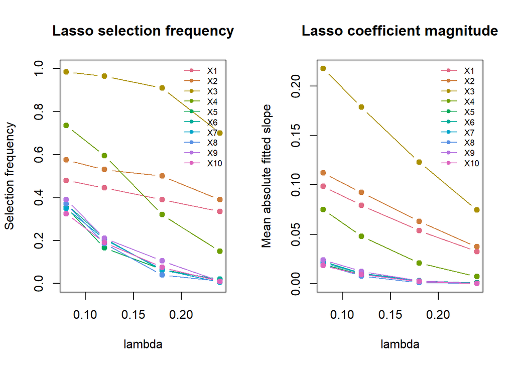

```r
par(mfrow = c(1, 2))

matplot(
  q1_lambdas, t(q1_selection_frequency),
  type = "b", pch = 19, lty = 1,
  col = q1_plot_colors,
  xlab = "lambda", ylab = "Selection frequency",
  main = "Lasso selection frequency",
  ylim = c(0, 1)
)
legend(
  "topright", legend = rownames(q1_selection_frequency),
  col = q1_plot_colors, lty = 1, pch = 19,
  bty = "n", cex = 0.7
)

matplot(
  q1_lambdas, t(q1_mean_absolute_slope),
  type = "b", pch = 19, lty = 1,
  col = q1_plot_colors,
  xlab = "lambda", ylab = "Mean absolute fitted slope",
  main = "Lasso coefficient magnitude"
)
legend(
  "topright", legend = rownames(q1_mean_absolute_slope),
  col = q1_plot_colors, lty = 1, pch = 19,
  bty = "n", cex = 0.7
)
```

**Show the workflow**

```r
par(mfrow = c(1, 1))
```

### (b)

**Show the workflow**

```r
q1_pair_outcomes <- sapply(
  seq_along(q1_lambdas),
  function(lambda_index) {
    q1_selected <- abs(q1_slopes[, 1:2, lambda_index]) > 1e-8
    q1_first <- q1_selected[, 1]
    q1_second <- q1_selected[, 2]

    c(
      only_first = mean(q1_first & !q1_second),
      only_second = mean(!q1_first & q1_second),
      both = mean(q1_first & q1_second),
      neither = mean(!q1_first & !q1_second)
    )
  }
)

dimnames(q1_pair_outcomes) <- list(
  c("only_first", "only_second", "both", "neither"),
  q1_lambdas
)

q1_pair_marginal_selection <- rbind(
  X1 = q1_selection_frequency["X1", ],
  X2 = q1_selection_frequency["X2", ]
)

q1_pair_marginal_selection
```

```
    0.08  0.12 0.18  0.24
X1 0.480 0.445 0.39 0.335
X2 0.575 0.530 0.50 0.390
```

**Show the workflow**

```r
q1_pair_outcomes
```

```
             0.08  0.12 0.18  0.24
only_first  0.410 0.415 0.37 0.315
only_second 0.505 0.500 0.48 0.370
both        0.070 0.030 0.02 0.020
neither     0.015 0.055 0.13 0.295
```

The marginal selection frequencies of $X_1$ and $X_2$ should be similar because the two predictors contain almost the same information. Lasso can select only one member of the pair because assigning the shared signal to one variable produces a sparse solution with a similar fitted response. Increasing lambda shifts outcomes toward selecting neither or only one variable.

### (c)

**Show the workflow**

```r
q1_signal_noise_summary <- data.frame(
  lambda = q1_lambdas,
  X3_selection_frequency = q1_selection_frequency["X3", ],
  X4_selection_frequency = q1_selection_frequency["X4", ],
  average_noise_selection_frequency = colMeans(
    q1_selection_frequency[paste0("X", 5:10), , drop = FALSE]
  )
)

q1_signal_noise_summary
```

```
     lambda X3_selection_frequency X4_selection_frequency
0.08   0.08                  0.985                  0.735
0.12   0.12                  0.965                  0.595
0.18   0.18                  0.910                  0.320
0.24   0.24                  0.700                  0.150
     average_noise_selection_frequency
0.08                        0.36000000
0.12                        0.19416667
0.18                        0.06833333
0.24                        0.01166667
```

$X_3$ usually has the highest selection frequency because it has the strongest true signal, while $X_4$ has a weaker signal. The noise variables have zero population coefficients, so their average selection frequency should generally be lower. However, a fitted zero does not prove that a population coefficient is zero, and a selected variable does not necessarily have unique information when another predictor is highly correlated with it.

## Question 2: Elastic net with an equal penalty mix

This question continues the simulation of Question 1. Generate the data exactly as in Question 1, with the same seed `43246`, so that the 200 repetitions produce the same datasets and the only change is the fitting method. Now fit the elastic net model with mixing parameter $\alpha=0.5$, which places equal weight on the $\ell_1$ and squared $\ell_2$ penalties. Use the `glmnet` package in R or `sklearn.linear_model.ElasticNet` in Python, with the same four penalties $\lambda\in\{0.08,0.12,0.18,0.24\}$ and the same fitting details as in Question 1. In R, additionally set `family = gaussian()` to avoid the response-rescaling convention of the default Gaussian solver and match the stated penalty mix. Make sure you understand which argument controls this mix in the package you use.

1. For every covariate and penalty, report the selection frequency, and draw the selection-frequency figure. Compare the frequencies with the lasso results from Question 1: which covariates change the most, and in which direction?
2. For the pair $(X_1,X_2)$, report the frequency of four mutually exclusive outcomes at each penalty: only the first covariate is selected, only the second is selected, both are selected, and neither is selected. Compare these frequencies with Question 1. Are the two covariates now properly selected together? Explain why the squared $\ell_2$ part of the penalty encourages the fit to keep both members of the pair.
3. Compare the average selection frequency among the noise covariates $X_5,\ldots,X_{10}$ with the lasso results at each penalty. Are the noise covariates still screened out as the penalty increases? At the same numerical value of $\lambda$, the elastic net applies a weaker $\ell_1$ threshold than the lasso; use this to explain any difference. State the penalties at which the elastic net selects both members of the pair while screening out most noise covariates.

## Solution to Question 2

### (a)

**Show the workflow**

```r
library(glmnet)

set.seed(43246)

n <- 120
p <- 10
n_reps <- 200
lambdas <- c(0.08, 0.12, 0.18, 0.24)

fit_penalized_model <- function(X, y, scales, lambda, alpha) {
  fit <- glmnet(
    X, y,
    family = gaussian(),
    alpha = alpha,
    lambda = lambda,
    intercept = TRUE,
    standardize = FALSE,
    thresh = 1e-18,
    maxit = 1000000
  )

  list(
    slopes = drop(as.matrix(fit$beta)) / scales,
    converged = fit$jerr == 0
  )
}

lasso_slopes <- array(0, dim = c(n_reps, p, length(lambdas)))
elastic_net_slopes <- array(0, dim = c(n_reps, p, length(lambdas)))
fit_convergence <- logical(n_reps * length(lambdas) * 2)
convergence_index <- 1

for (replication in seq_len(n_reps)) {
  x1 <- rnorm(n)
  x2 <- 0.999 * x1 + sqrt(1 - 0.999^2) * rnorm(n)
  x_remaining <- matrix(rnorm(n * (p - 2)), nrow = n, ncol = p - 2)
  X_raw <- cbind(x1, x2, x_remaining)

  y <- 0.15 * x1 + 0.15 * x2 +
    0.30 * X_raw[, 3] + 0.15 * X_raw[, 4] + rnorm(n)

  X_centered <- sweep(X_raw, 2, colMeans(X_raw), "-")
  scales <- sqrt(colMeans(X_centered^2))
  X <- sweep(X_centered, 2, scales, "/")
  y_centered <- y - mean(y)

  for (lambda_index in seq_along(lambdas)) {
    lambda <- lambdas[lambda_index]

    lasso_fit <- fit_penalized_model(
      X, y_centered, scales, lambda, alpha = 1
    )
    elastic_net_fit <- fit_penalized_model(
      X, y_centered, scales, lambda, alpha = 0.5
    )

    lasso_slopes[replication, , lambda_index] <- lasso_fit$slopes
    elastic_net_slopes[replication, , lambda_index] <- elastic_net_fit$slopes

    fit_convergence[convergence_index] <- lasso_fit$converged
    fit_convergence[convergence_index + 1] <- elastic_net_fit$converged
    convergence_index <- convergence_index + 2
  }
}

stopifnot(all(fit_convergence))

selection_frequency <- function(slopes) {
  result <- sapply(
    seq_len(dim(slopes)[3]),
    function(lambda_index) {
      colMeans(abs(slopes[, , lambda_index]) > 1e-8)
    }
  )
  dimnames(result) <- list(paste0("X", seq_len(p)), lambdas)
  result
}

elastic_selection <- selection_frequency(elastic_net_slopes)
lasso_selection <- selection_frequency(lasso_slopes)

elastic_selection
```

```
     0.08  0.12  0.18  0.24
X1  0.950 0.950 0.940 0.910
X2  0.980 0.975 0.975 0.935
X3  1.000 0.985 0.985 0.965
X4  0.875 0.800 0.720 0.600
X5  0.635 0.475 0.310 0.175
X6  0.610 0.465 0.340 0.205
X7  0.590 0.450 0.310 0.215
X8  0.660 0.505 0.345 0.190
X9  0.630 0.495 0.350 0.210
X10 0.620 0.455 0.270 0.200
```

**Show the workflow**

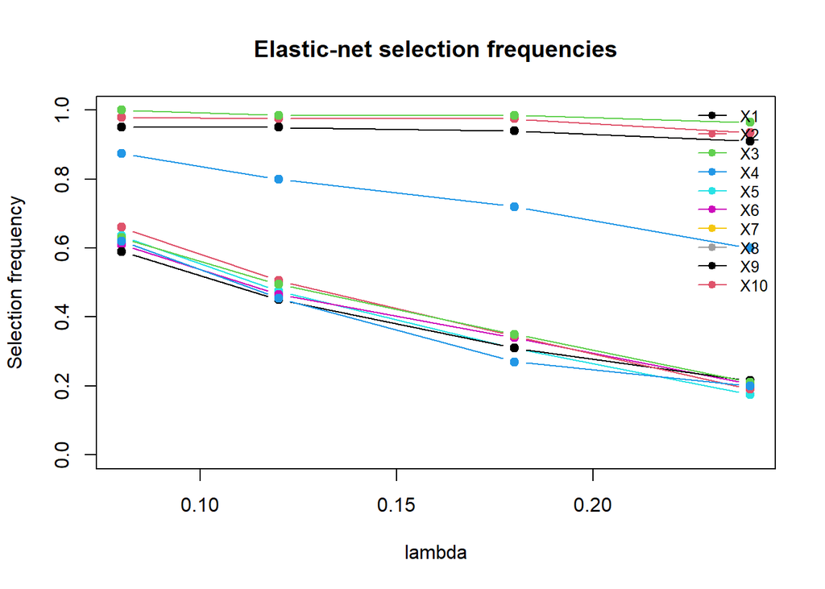

```r
matplot(
  lambdas, t(elastic_selection),
  type = "b", pch = 19, lty = 1,
  xlab = "lambda", ylab = "Selection frequency",
  main = "Elastic-net selection frequencies",
  ylim = c(0, 1)
)
legend(
  "topright", legend = rownames(elastic_selection),
  col = seq_len(p), lty = 1, pch = 19,
  bty = "n", cex = 0.8
)
```

The same four penalties are applied to every simulated dataset. The elastic net selection frequencies show how often each predictor receives a nonzero fitted slope. Increasing lambda makes the penalty stronger, so selection generally becomes less frequent. The lasso fits are computed in the same loop to provide the requested comparison with Question 1.

### (b)

**Show the workflow**

```r
pair_outcomes <- function(slopes) {
  pair_selected <- abs(slopes[, 1:2, ]) > 1e-8

  result <- sapply(
    seq_len(dim(slopes)[3]),
    function(lambda_index) {
      first <- pair_selected[, 1, lambda_index]
      second <- pair_selected[, 2, lambda_index]

      c(
        only_first = mean(first & !second),
        only_second = mean(!first & second),
        both = mean(first & second),
        neither = mean(!first & !second)
      )
    }
  )

  dimnames(result) <- list(
    c("only_first", "only_second", "both", "neither"),
    lambdas
  )
  result
}

lasso_pair_outcomes <- pair_outcomes(lasso_slopes)
elastic_pair_outcomes <- pair_outcomes(elastic_net_slopes)

pair_marginal_selection <- rbind(
  lasso_X1 = lasso_selection["X1", ],
  lasso_X2 = lasso_selection["X2", ],
  elastic_net_X1 = elastic_selection["X1", ],
  elastic_net_X2 = elastic_selection["X2", ]
)

pair_marginal_selection
```

```
                0.08  0.12  0.18  0.24
lasso_X1       0.480 0.445 0.390 0.335
lasso_X2       0.575 0.530 0.500 0.390
elastic_net_X1 0.950 0.950 0.940 0.910
elastic_net_X2 0.980 0.975 0.975 0.935
```

**Show the workflow**

```r
lasso_pair_outcomes
```

```
             0.08  0.12 0.18  0.24
only_first  0.410 0.415 0.37 0.315
only_second 0.505 0.500 0.48 0.370
both        0.070 0.030 0.02 0.020
neither     0.015 0.055 0.13 0.295
```

**Show the workflow**

```r
elastic_pair_outcomes
```

```
            0.08  0.12  0.18  0.24
only_first  0.02 0.015 0.005 0.005
only_second 0.05 0.040 0.040 0.030
both        0.93 0.935 0.935 0.905
neither     0.00 0.010 0.020 0.060
```

Compared with lasso, elastic net should increase the frequency of selecting both $X_1$ and $X_2$ together. The squared $\ell_2$ term discourages the model from assigning all of the shared signal to only one member of the highly correlated pair. The marginal selection frequencies of the two variables remain similar because they carry nearly the same information.

### (c)

**Show the workflow**

```r
noise_indices <- 5:10

noise_comparison <- data.frame(
  lambda = lambdas,
  lasso_noise_frequency = colMeans(lasso_selection[noise_indices, , drop = FALSE]),
  elastic_net_noise_frequency = colMeans(
    elastic_selection[noise_indices, , drop = FALSE]
  ),
  lasso_both_pair_frequency = lasso_pair_outcomes["both", ],
  elastic_net_both_pair_frequency = elastic_pair_outcomes["both", ]
)

noise_comparison
```

```
     lambda lasso_noise_frequency elastic_net_noise_frequency
0.08   0.08            0.36000000                   0.6241667
0.12   0.12            0.19416667                   0.4741667
0.18   0.18            0.06833333                   0.3208333
0.24   0.24            0.01166667                   0.1991667
     lasso_both_pair_frequency elastic_net_both_pair_frequency
0.08                      0.07                           0.930
0.12                      0.03                           0.935
0.18                      0.02                           0.935
0.24                      0.02                           0.905
```

At the same numerical lambda, elastic net has a weaker $\ell_1$ component than lasso because only half of its penalty is the $\ell_1$ penalty. It can therefore retain more variables, including some noise variables. The useful compromise is a penalty where elastic net selects both correlated predictors while the average noise selection frequency remains low.

## Question 3: Coordinate descent and the lasso path

This question asks you to implement coordinate descent yourself and use it to compute a complete lasso path. Create one simulated dataset with $n=100$ observations and $p=3$ covariates. Generate three covariates as independent standard normal vectors of length $n$, and generate the response as

$$Y
=
1.5+X_1-2X_2+\epsilon,$$

where $\epsilon$ is a vector of $n$ independent standard normal errors, independent of the covariates. The third covariate does not appear in the generating equation. Use seed `43247`. Center the response and center and standardize each covariate using divisor $n$. The intercept is fitted separately as the mean of the response and is not penalized.

The lasso objective is

$$L_\lambda(\boldsymbol\beta)
=
\frac{1}{2n}
\left\lVert
\widetilde{\mathbf y}-\mathbf X\boldsymbol\beta
\right\rVert_2^2
+
\lambda\lVert\boldsymbol\beta\rVert_1,$$

where $\widetilde{\mathbf y}$ is the centered response and $\mathbf X$ is the standardized covariate matrix. Coordinate descent updates one slope at a time while holding the other slopes fixed. For coordinate $j$, form the residual that leaves covariate $j$ out of the current fit, and compute the score $a_j$ as the mean of the elementwise product of covariate $j$ and that residual. Because each standardized column satisfies $\frac{1}{n}\mathbf x_j^{\mathsf T}\mathbf x_j=1$, the update is the soft-thresholding rule from the Week 4 lecture:

$$\widehat\beta_j\leftarrow S(a_j,\lambda),
\qquad
S(a,\lambda)=\operatorname{sign}(a)(|a|-\lambda)_+.$$

Follow this procedure:

1. Fix a value of $\lambda$ and loop over the indices $j=1,\ldots,p$ until the coefficients stop changing. For each $j$, form the residual without covariate $j$, compute its score, and save the soft-thresholded value as the new $\widehat\beta_j$ before moving to the next index.
2. Check convergence after each complete cycle: stop when the largest absolute coefficient change is below a small tolerance, such as $10^{-8}$. Record the fitted vector for that $\lambda$.
3. Then reduce $\lambda$ to the next grid value and start the next fit from the current coefficients (a warm start). Repeat for the whole grid

$$\lambda\in\{2.5,2.0,1.5,1.0,0.6,0.4,0.25,0.15,0.08,0.03\}.$$

1. Implement the procedure. Report the fitted coefficient vector at each grid value in a small table, and verify that every fit converged. Compute $\lambda_{\max}=\lVert\frac{1}{n}\mathbf X^{\mathsf T}\widetilde{\mathbf y}\rVert_\infty$ and check that all slopes are zero for grid values at or above it.
2. Plot the coefficient path: one curve per covariate, with the fitted slope on the vertical axis and $\log(\lambda)$ on the horizontal axis. Describe the order in which the covariates enter the model and explain that order using the sizes of the true coefficients.
3. The third covariate has a zero population coefficient. Does it enter the path at small penalties in your run? Compare the fit at the smallest grid value with a least-squares fit on the same standardized data, and explain why the two are close but not identical.

## Solution to Question 3

### (a)

**Show the workflow**

```r
set.seed(43247)

n <- 100
p <- 3
X_raw <- matrix(rnorm(n * p), nrow = n, ncol = p)
y <- 1.5 + X_raw[, 1] - 2 * X_raw[, 2] + rnorm(n)

X_centered <- sweep(X_raw, 2, colMeans(X_raw), "-")
X <- sweep(X_centered, 2, sqrt(colMeans(X_centered^2)), "/")
y_centered <- y - mean(y)

soft_threshold <- function(value, lambda) {
  sign(value) * max(abs(value) - lambda, 0)
}

coordinate_descent <- function(X, y_centered, lambda, beta_start,
                               tolerance = 1e-8, max_iterations = 10000) {
  beta <- beta_start

  for (iteration in seq_len(max_iterations)) {
    beta_previous <- beta

    for (j in seq_len(ncol(X))) {
      residual_without_j <- y_centered - drop(X %*% beta) + X[, j] * beta[j]
      score <- mean(X[, j] * residual_without_j)
      beta[j] <- soft_threshold(score, lambda)
    }

    if (max(abs(beta - beta_previous)) < tolerance) {
      return(list(coefficients = beta, iterations = iteration, converged = TRUE))
    }
  }

  list(coefficients = beta, iterations = max_iterations, converged = FALSE)
}

lambdas <- c(2.5, 2.0, 1.5, 1.0, 0.6, 0.4, 0.25, 0.15, 0.08, 0.03)
path_results <- vector("list", length(lambdas))
beta_start <- rep(0, p)

for (lambda_index in seq_along(lambdas)) {
  fit <- coordinate_descent(
    X, y_centered, lambdas[lambda_index], beta_start
  )

  path_results[[lambda_index]] <- data.frame(
    lambda = lambdas[lambda_index],
    beta_1 = fit$coefficients[1],
    beta_2 = fit$coefficients[2],
    beta_3 = fit$coefficients[3],
    iterations = fit$iterations,
    converged = fit$converged
  )
  beta_start <- fit$coefficients
}

path_table <- do.call(rbind, path_results)
lambda_max <- max(abs(crossprod(X, y_centered) / n))
zero_slope_check <- data.frame(
  lambda = path_table$lambda[path_table$lambda >= lambda_max],
  all_slopes_zero = apply(
    abs(path_table[path_table$lambda >= lambda_max,
                   c("beta_1", "beta_2", "beta_3")]) <= 1e-8,
    1,
    all
  )
)

path_table
```

```
   lambda    beta_1     beta_2 beta_3 iterations converged
1    2.50 0.0000000  0.0000000      0          1      TRUE
2    2.00 0.0000000  0.0000000      0          1      TRUE
3    1.50 0.0000000 -0.3272012      0          2      TRUE
4    1.00 0.0000000 -0.8272012      0          2      TRUE
5    0.60 0.2834843 -1.2495197      0          5      TRUE
6    0.40 0.5005757 -1.4666112      0          5      TRUE
7    0.25 0.6633943 -1.6294298      0          5      TRUE
8    0.15 0.7719400 -1.7379755      0          5      TRUE
9    0.08 0.8479220 -1.8139575      0          5      TRUE
10   0.03 0.9021949 -1.8682304      0          5      TRUE
```

**Show the workflow**

```r
lambda_max
```

```
[1] 1.827201
```

**Show the workflow**

```r
all(path_table$converged)
```

```
[1] TRUE
```

**Show the workflow**

```r
zero_slope_check
```

```
  lambda all_slopes_zero
1    2.5            TRUE
2    2.0            TRUE
```

The same penalty is applied to all three slopes within one fit. Coordinate descent estimates the coefficients for one fixed lambda, and the outer loop repeats it for every value in the grid. The previous solution is used as a warm start for the next, smaller lambda.

The largest penalty for which all lasso slopes are zero is

$$\lambda_{\max} =
\left\|\frac{1}{n}\mathbf X^{\mathsf T}\widetilde{\mathbf y}\right\|_\infty.$$

Thus, every grid value at least as large as `lambda_max` should produce zero slopes, up to numerical tolerance.

### (b)

**Show the workflow**

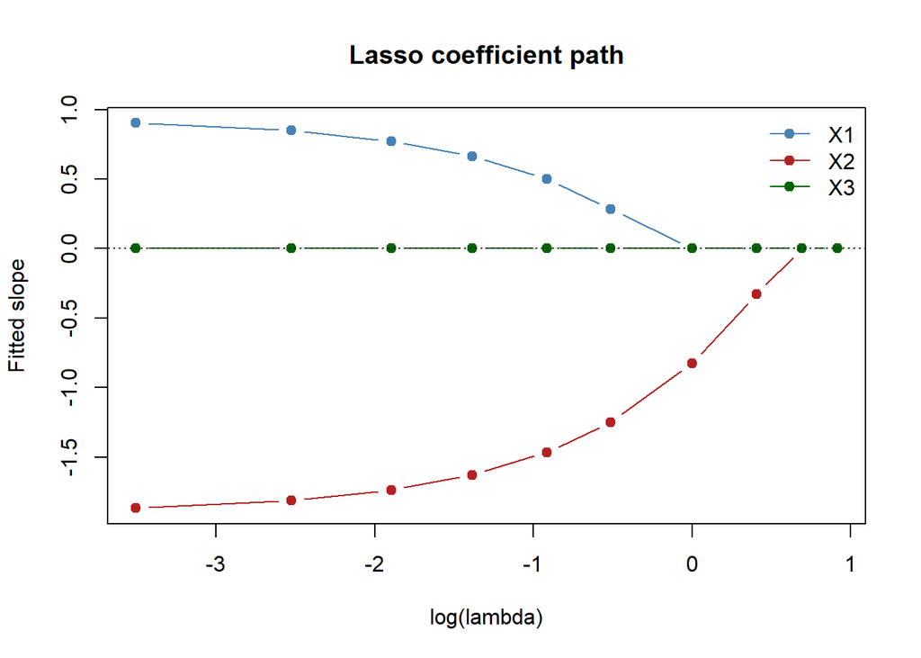

```r
coefficient_path <- as.matrix(
  path_table[, c("beta_1", "beta_2", "beta_3")]
)

matplot(
  log(lambdas), coefficient_path,
  type = "b", pch = 19, lty = 1,
  col = c("steelblue", "firebrick", "darkgreen"),
  xlab = "log(lambda)", ylab = "Fitted slope",
  main = "Lasso coefficient path"
)
abline(h = 0, lty = 3)
legend(
  "topright", legend = c("X1", "X2", "X3"),
  col = c("steelblue", "firebrick", "darkgreen"),
  lty = 1, pch = 19, bty = "n"
)
```

As lambda decreases, the penalty becomes weaker and the slopes move away from zero. Since the true coefficient of $X_2$ has the largest absolute value, $X_2$ generally enters first. $X_1$ has a weaker signal and enters later. $X_3$ has zero population coefficient, but random sample correlation can make it enter when the penalty is small.

### (c)

**Show the workflow**

```r
least_squares_coefficients <- drop(
  solve(crossprod(X), crossprod(X, y_centered))
)

smallest_lambda_coefficients <- as.numeric(
  path_table[nrow(path_table), c("beta_1", "beta_2", "beta_3")]
)

comparison <- rbind(
  lasso_at_smallest_lambda = smallest_lambda_coefficients,
  least_squares = least_squares_coefficients
)
colnames(comparison) <- c("beta_1", "beta_2", "beta_3")
comparison
```

```
                            beta_1    beta_2      beta_3
lasso_at_smallest_lambda 0.9021949 -1.868230 0.000000000
least_squares            0.9328926 -1.901631 0.008847341
```

The third predictor can enter at small penalties even though its population coefficient is zero, because a finite sample can create an accidental association with the response. The lasso estimates at the smallest lambda are close to least squares because the penalty is weak, but they are not identical because lasso still shrinks the coefficients toward zero.

## Question 4: Tuning and comparing penalized regressions for diabetes prediction

The supplied `data/diabetes.csv` contains 442 observations of ten baseline covariates and the quantitative response `y`. The file `data/diabetes-split-folds.csv` assigns 353 observations to the training set and 89 observations to the final test set; it also supplies ten fold labels for the training observations.

Tune three penalized regressions (lasso, ridge, and elastic net with mixing parameter $\alpha=0.5$) for predicting `y` from the ten covariates. Using only the training observations, perform ten-fold cross-validation with the supplied folds for each method and select each penalty by the smallest mean cross-validation error. In R, use `cv.glmnet` with its default Gaussian solver and package-generated penalty grids. In Python, use `GridSearchCV` with 61 logarithmically spaced penalty values from $10^{-4}$ to $10^2$ for each method, placing `StandardScaler` inside a `Pipeline`. Make sure you understand which argument selects the penalty family. In every fit, estimate the covariate means and scales from the observations used for that fit, center the response, and leave the intercept unpenalized. The package-specific grids and penalty conventions can give different tuning results across languages.

Select the method with the smallest minimum cross-validation error. Produce the cross-validation plot for each of the three fits (in R, the default plot of a `cv.glmnet` object) and a table comparing the three selected penalties and their cross-validation errors. Then refit the chosen model on all training observations, evaluate the final test set once, and report the selected method, its penalty, and the test error.

## Solution to Question 4

**Show the workflow**

```r
split_folds <- read.csv(
  "C:/Users/melik/Documents/UIUC/courses/STAT432 - Zhu/homework/week-04/data/diabetes-split-folds.csv",
  check.names = FALSE
)

diabetes <- read.csv(
  "C:/Users/melik/Documents/UIUC/courses/STAT432 - Zhu/homework/week-04/data/diabetes.csv",
  check.names = FALSE
)

head(split_folds)
```

```
  row_id split cv_fold
1      1  test      NA
2      2 train       3
3      3  test      NA
4      4  test      NA
5      5 train       3
6      6  test      NA
```

**Show the workflow**

```r
head(diabetes)
```

```
           age         sex         bmi           bp           s1          s2
1  0.038075906  0.05068012  0.06169621  0.021872386 -0.044223498 -0.03482076
2 -0.001882017 -0.04464164 -0.05147406 -0.026327528 -0.008448724 -0.01916334
3  0.085298906  0.05068012  0.04445121 -0.005670422 -0.045599451 -0.03419447
4 -0.089062939 -0.04464164 -0.01159501 -0.036656081  0.012190569  0.02499059
5  0.005383060 -0.04464164 -0.03638469  0.021872386  0.003934852  0.01559614
6 -0.092695478 -0.04464164 -0.04069594 -0.019441826 -0.068990650 -0.07928784
            s3           s4           s5           s6   y
1 -0.043400846 -0.002592262  0.019907486 -0.017646125 151
2  0.074411564 -0.039493383 -0.068331547 -0.092204050  75
3 -0.032355932 -0.002592262  0.002861309 -0.025930339 141
4 -0.036037570  0.034308859  0.022687745 -0.009361911 206
5  0.008142084 -0.002592262 -0.031987639 -0.046640874 135
6  0.041276824 -0.076394504 -0.041176167 -0.096346157  97
```

**Show the workflow**

```r
features <- c(
  "age", "sex", "bmi", "bp", "s1",
  "s2", "s3", "s4", "s5", "s6"
)

diabetes$row_id <- seq_len(nrow(diabetes))
match_index <- match(split_folds$row_id, diabetes$row_id)
stopifnot(!anyNA(match_index), anyDuplicated(split_folds$row_id) == 0)

course_data <- cbind(
  split_folds,
  diabetes[match_index, setdiff(names(diabetes), "row_id"), drop = FALSE]
)

X_raw_all <- as.matrix(course_data[, features])
y_all <- course_data$y
is_train <- course_data$split == "train"

X_train <- X_raw_all[is_train, , drop = FALSE]
y_train <- y_all[is_train]
X_test <- X_raw_all[!is_train, , drop = FALSE]
y_test <- y_all[!is_train]
fold <- course_data$cv_fold[is_train]

dim(X_train)
```

```
[1] 353  10
```

**Show the workflow**

```r
dim(X_test)
```

```
[1] 89 10
```

**Show the workflow**

```r
table(fold)
```

```
fold
 1  2  3  4  5  6  7  8  9 10
36 36 36 35 35 35 35 35 35 35
```

**Show the workflow**

```r
library(glmnet)

fit_lasso <- cv.glmnet(
  X_train, y_train,
  family = "gaussian",
  alpha = 1,
  foldid = fold,
  type.measure = "mse",
  standardize = TRUE
)

fit_ridge <- cv.glmnet(
  X_train, y_train,
  family = "gaussian",
  alpha = 0,
  foldid = fold,
  type.measure = "mse",
  standardize = TRUE
)

fit_elastic_net <- cv.glmnet(
  X_train, y_train,
  family = "gaussian",
  alpha = 0.5,
  foldid = fold,
  type.measure = "mse",
  standardize = TRUE
)

fits <- list(
  lasso = fit_lasso,
  ridge = fit_ridge,
  elastic_net = fit_elastic_net
)

model_summary <- data.frame(
  method = names(fits),
  lambda_min = vapply(fits, function(fit) fit$lambda.min, numeric(1)),
  cv_mse = vapply(fits, function(fit) min(fit$cvm), numeric(1))
)

model_summary
```

```
                 method lambda_min   cv_mse
lasso             lasso 0.09945587 3068.424
ridge             ridge 4.61633253 3080.365
elastic_net elastic_net 0.16514002 3069.013
```

**Show the workflow**

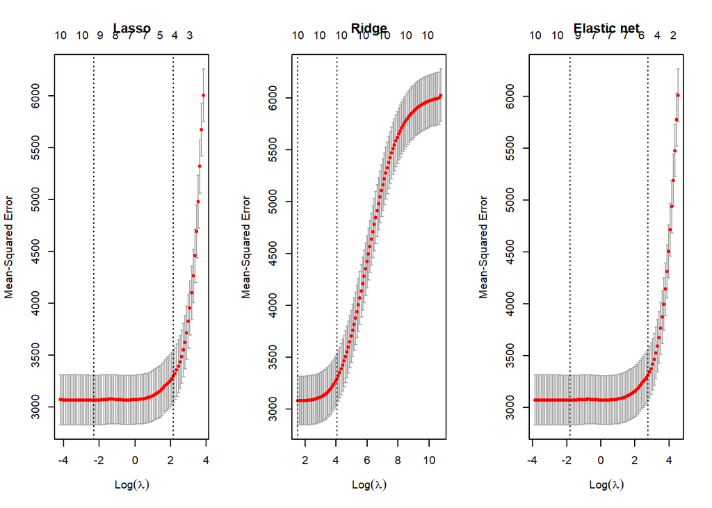

```r
par(mfrow = c(1, 3))
plot(fit_lasso, main = "Lasso")
plot(fit_ridge, main = "Ridge")
plot(fit_elastic_net, main = "Elastic net")
```

**Show the workflow**

```r
par(mfrow = c(1, 1))
```

**Show the workflow**

```r
lasso_coefficients <- data.frame(
  parameter = rownames(as.matrix(coef(fit_lasso, s = "lambda.min"))),
  estimate = as.numeric(coef(fit_lasso, s = "lambda.min"))
)

lasso_coefficients
```

```
     parameter    estimate
1  (Intercept)  152.610726
2          age   -1.208579
3          sex -243.644507
4          bmi  515.516368
5           bp  352.246548
6           s1 -593.308859
7           s2  368.289572
8           s3    0.000000
9           s4   44.653494
10          s5  690.314266
11          s6   61.914544
```

**Show the workflow**

```r
final_lasso <- glmnet(
  X_train, y_train,
  family = "gaussian",
  alpha = 1,
  lambda = fit_lasso$lambda.min,
  standardize = TRUE
)

test_predictions <- predict(final_lasso, newx = X_test, s = fit_lasso$lambda.min)
test_mse <- mean((y_test - as.numeric(test_predictions))^2)

final_results <- data.frame(
  selected_model = "lasso",
  lambda = fit_lasso$lambda.min,
  test_mse = test_mse
)

final_results
```

```
  selected_model     lambda test_mse
1          lasso 0.09945587 2731.794
```